# **Analysis of Teachers' Gender Stereotypes**

### **May 15, 2022**

# **Table of Contents:**

1. Introduction
2. Description of Data
3. Required Tools and Libraries
4. Part I. The Impact of Teachers' Gender Stereotypes on Students' Standardized Math Test Score
5. Part II. Establishing a Causal Link - Exogeneity of Assignment of Students to Teachers with Gender Stereotypes
6. Part III. Prediction of Teachers' Gender Stereotypes

## **Introduction**

**Despite the fact that gender differences in educational outcomes has been narrowed impressively, boys have been showing better performance than girls in math. Math performance has been considered a good predictor of outcomes in the labor market. Recent studies have focused on explaining the gender gap in math performance in the context of gender stereotypes. If one has the prepreceptions that one gender generally performs worse in math than the other, it may cause discrimination. Stereotypes such as girls cannot perform as well as boys do in math could contribute to the grils' low confidence in math, and in turns, girls' worse performance in math. If stereotypes are communated by teachers, the effects can be more significant as their close interaction with students. Psychological studies have documented that teachers tend to believe math is more difficult for girls than boys. Girls exposed to such stereotypes communicated by their teachers are likley to be negatively affected in terms of their academic performance in math.**

**The main question of interest of this project is whether the exposure of students to teacher stereotypes has an impact on student academic performance in math. In addition, this projects attempts to predict teacher stereotypes given the characteristics of teachers.**

## **Description of Data**

**The dataset used in this analysis is a survey data of 145 middle schools in Italy. The questionnare was anwered by around 1400 math and literature teachers. An implicit gender stereotypes value is calculated based on the teachers' response to the survey questions. The dataset also includes the information about students' background, standardized test score and teachers' backgroud (Michela Carlana, Implicit Stereotypes: Evidence from Teachers’ Gender Bias, The Quarterly Journal of Economics, Volume 134, Issue 3, August 2019, Pages 1163–1224).**

## **Required Tools**

Following libraries are imported for data analysis:

```python
import pandas as pd
import numpy as np
import matplotlib.pyplot as plt
import seaborn as sns
```

```python
from sklearn.linear_model import LinearRegression
from scipy import stats
import statsmodels.api as sm
import statsmodels.formula.api as smf
```

## **Data Collection and Processing**

Importing the data using pandas is the first step. Then, a few data processing steps are conducted, such as mutating new variables using the existing variables, filtering the dataset by certain conditions, and aggregating the data at teacher level for further analysis.

```python
### read csv data
url = 'https://raw.githubusercontent.com/xuetingpi/xuetingpi.github.io/main/stereotypes.csv'
stereo = pd.read_csv(url)
stereo.head()
```

|  | anno_scuola8 | INS_MAT8 | female | stereotype_mat | stdinvalsi_mat8 | confidence_mat | high_edu_mother | teacher_female_mat | t_N_mat | mate_mate | figli_mat | daughters_mat | t_age_mat | full_contract_mat | t_high_edum_mat |
| --- | --- | --- | --- | --- | --- | --- | --- | --- | --- | --- | --- | --- | --- | --- | --- |
| 0 | 10 | 20401.0 | 1 | 1.664648 | -0.347878 | NaN | 0 | 1 | 1 | 1 | 1 | 0 | 45 | 1 | 0 |
| 1 | 10 | 20401.0 | 1 | 1.664648 | 0.167720 | NaN | 0 | 1 | 1 | 1 | 1 | 0 | 45 | 1 | 0 |
| 2 | 10 | 20401.0 | 0 | 1.664648 | 1.070015 | NaN | 0 | 1 | 1 | 1 | 1 | 0 | 45 | 1 | 0 |
| 3 | 10 | 20401.0 | 0 | 1.664648 | 0.038820 | NaN | 0 | 1 | 1 | 1 | 1 | 0 | 45 | 1 | 0 |
| 4 | 10 | 20401.0 | 0 | 1.664648 | -1.379072 | NaN | 0 | 1 | 1 | 1 | 1 | 0 | 45 | 1 | 0 |

```python
#### create new variables
stereo['gender'] = np.where(stereo['female']== 1, 'Female', 'Male')

#### add interaction variables
stereo['fem_stereotype_mat'] = stereo['female']*stereo['stereotype_mat']
stereo['fem_high_edu_mother'] = stereo['female']*stereo['high_edu_mother']
### subsetting data
### drop observations with missing stereotype value of math teacher
df_math = stereo[stereo['stereotype_mat'].notna()]
```

```python
#### aggregate data at teacher level for prediction of teacher's stereotype in the last pat
#### In the original dataset, observation unit is student. 'INS_MAT8' is the math teacher ID.
#### Grouping by the original dataset and keep any row within the group will keep the information of the math teacher.
#### For this step, I keep the first row.
teacher = df_math.groupby('INS_MAT8').first()

#### Student's information is not necessary for the object of prediction of teacher type, so I only keep variables related to teacher characteristics for this dataset.
df_teacher = teacher[['stereotype_mat','teacher_female_mat', 't_N_mat', 'daughters_mat', 'figli_mat', 't_age_mat', 'full_contract_mat', 't_high_edum_mat']]
```

## **Part I. The Impact of Teachers' Gender Stereotypes on Students' Standardized Math Test Score**

## **Empirical Data Analysis**

Before investigating whether teacher stereotypes have any different impact on students score between female and male students, difference in academic performance in math of female and male students should be explored. This session presents some statistical graphs for visualizing the independent variables and dependent of interest, and the relationship between the dependent and independent variables as well.

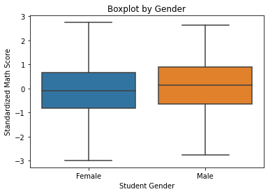

```python
#### student's score v.s. gender, teacher type
box = sns.boxplot(x="gender", y="stdinvalsi_mat8", data = df_math)
box.set(xlabel = 'Student Gender',ylabel = 'Standardized Math Score', title = 'Boxplot by Gender')
plt.show()
```

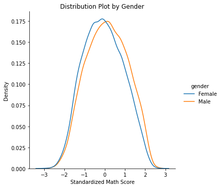

```python
dist = sns.displot(df_math, x="stdinvalsi_mat8", hue="gender", kind="kde")
dist.set(xlabel = 'Standardized Math Score', title = 'Distribution Plot by Gender')
plt.show()
```

The boxplot and the distribution plot of standardized math score by student gender indicate the difference in math performance between female and male students. Male students perform better than female student on average. We might think about the possibility of teachers' characteristics influencing the gender gap in math performance. So, let's plot the distribution of the math score by student gender and by teacher gender.

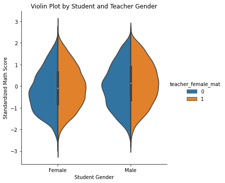

```python
vio = sns.catplot(data=df_math, kind="violin", x="gender", y="stdinvalsi_mat8", hue="teacher_female_mat", split=True)
vio.set(xlabel = 'Student Gender',ylabel = 'Standardized Math Score', title = 'Violin Plot by Student and Teacher Gender')
plt.show()
```

As shown in the plot above, for male students of female or male teacher, their score distribution are very similar, indicating male students of male or female teachers can perform similaly good. However, for female students of male teacher and female teacher, their score distribution have some difference. Female students of male teacher have lower average score than female students of female teachers. A possible explanation could be that female math teachers are less likely to have such stereotypes against girls' success in math performance because of the female teacher's own high achievement in math. Therefore, female students in a female math teacher's class are less likely to be exposed to gender stereotypes, and thus have better performance than their counterparts in male math teacher's class. Suppose we give some credibility to the story mentioned above, we can examine whether there are different relationships between math teacher stereotype and students' math scores for female and male students.

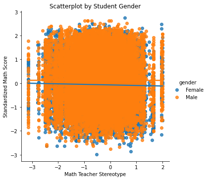

```python
scat = sns.lmplot(data = df_math, x = 'stereotype_mat', y = 'stdinvalsi_mat8', hue = 'gender')
scat.set(xlabel = 'Math Teacher Stereotype',ylabel = 'Standardized Math Score', title = 'Scatterplot by Student Gender')
plt.show()
```

As we can see from the separate regression lines by student gender in the scatterplot, male students are almost unaffected by the math teacher stereotype, but female students are negatively affected by the math teacher stereotype. The slope of the regression line (blue) for female students is negative. I further present some linear regression results below to statsitically show the impact of exposure to math teacher stereotype on students' math score.

```python
###### regress standardized math score on female indicator and interaction between female indictor and math teacher stereotype
mod = smf.ols(formula = 'stdinvalsi_mat8 ~ female + fem_stereotype_mat', data = df_math)
res = mod.fit()
print(res.summary())
```

```
                            OLS Regression Results
==============================================================================
Dep. Variable:        stdinvalsi_mat8   R-squared:                       0.009
Model:                            OLS   Adj. R-squared:                  0.009
Method:                 Least Squares   F-statistic:                     131.7
Date:                Sun, 15 May 2022   Prob (F-statistic):           1.16e-57
Time:                        15:53:45   Log-Likelihood:                -42763.
No. Observations:               30359   AIC:                         8.553e+04
Df Residuals:                   30356   BIC:                         8.556e+04
Df Model:                           2
Covariance Type:            nonrobust
======================================================================================
                         coef    std err          t      P>|t|      [0.025      0.975]
--------------------------------------------------------------------------------------
Intercept              0.1197      0.008     14.995      0.000       0.104       0.135
female                -0.1917      0.012    -15.999      0.000      -0.215      -0.168
fem_stereotype_mat    -0.0226      0.009     -2.498      0.013      -0.040      -0.005
==============================================================================
Omnibus:                     1714.755   Durbin-Watson:                   1.681
Prob(Omnibus):                  0.000   Jarque-Bera (JB):              649.641
Skew:                           0.034   Prob(JB):                    8.56e-142
Kurtosis:                       2.287   Cond. No.                         2.84
==============================================================================

Notes:
[1] Standard Errors assume that the covariance matrix of the errors is correctly specified.
```

```python
### add student controls - teacher's stereotype steadily matters
mod = smf.ols(formula = 'stdinvalsi_mat8 ~ female + fem_stereotype_mat + high_edu_mother + fem_high_edu_mother', data = df_math)
res = mod.fit()
print(res.summary())
```

```
                            OLS Regression Results
==============================================================================
Dep. Variable:        stdinvalsi_mat8   R-squared:                       0.075
Model:                            OLS   Adj. R-squared:                  0.074
Method:                 Least Squares   F-statistic:                     611.3
Date:                Sun, 15 May 2022   Prob (F-statistic):               0.00
Time:                        15:55:18   Log-Likelihood:                -41718.
No. Observations:               30359   AIC:                         8.345e+04
Df Residuals:                   30354   BIC:                         8.349e+04
Df Model:                           4
Covariance Type:            nonrobust
=======================================================================================
                          coef    std err          t      P>|t|      [0.025      0.975]
---------------------------------------------------------------------------------------
Intercept              -0.0967      0.010     -9.527      0.000      -0.117      -0.077
female                 -0.1965      0.015    -13.173      0.000      -0.226      -0.167
fem_stereotype_mat     -0.0257      0.009     -2.933      0.003      -0.043      -0.009
high_edu_mother         0.5120      0.016     32.791      0.000       0.481       0.543
fem_high_edu_mother     0.0099      0.022      0.444      0.657      -0.034       0.053
==============================================================================
Omnibus:                      988.681   Durbin-Watson:                   1.721
Prob(Omnibus):                  0.000   Jarque-Bera (JB):              460.176
Skew:                           0.029   Prob(JB):                    1.19e-100
Kurtosis:                       2.400   Cond. No.                         6.61
==============================================================================

Notes:
[1] Standard Errors assume that the covariance matrix of the errors is correctly specified.
```

In this regression, I add additional student baseline characteristics controls. The results provide more information such as students with high education mother have higher math scores. Notice that adding additional controls have not changed the estimates on exposure to teachers' gender stereotypes. Therefore, the regression results suggest that math teachers' gender stereotypes have a negative impact on the standardized math test scores of female students.

## **Part II. Establishing a Causal Link - Exogeneity of Assignment of Students to Teachers with Gender Stereotypes**

Though we have inferred from regression results from Part I that math teachers' stereotypes have negative impact on female students' math performance, we cannot claim the relationship is causal. If students assigned to teachers with gender stereotypes are intrinsically different from the students assigned to teachers without gender stereotypes, the estimates of the impact of teachers' gender stereotypes on students' performance will be biased. Therefore, in this session, I run a few robustness checks to validate the exogeneity of assignment of students to teachers with gender stereotypes. Simply speaking, we want to see a statistically insignificant relationship between the related students characteristics with teachers' stereotype, which will supports that students exposed to teachers' gender stereotypes are have no baseline difference than the students not exposed to teachers' gender stereotypes.

```python
mod = smf.ols(formula = 'stereotype_mat ~ female', data = df_math)
res = mod.fit()
print(res.summary())
```

```
                            OLS Regression Results
==============================================================================
Dep. Variable:         stereotype_mat   R-squared:                       0.000
Model:                            OLS   Adj. R-squared:                 -0.000
Method:                 Least Squares   F-statistic:                  0.006236
Date:                Sun, 15 May 2022   Prob (F-statistic):              0.937
Time:                        15:55:22   Log-Likelihood:                -42509.
No. Observations:               32642   AIC:                         8.502e+04
Df Residuals:                   32640   BIC:                         8.504e+04
Df Model:                           1
Covariance Type:            nonrobust
==============================================================================
                 coef    std err          t      P>|t|      [0.025      0.975]
------------------------------------------------------------------------------
Intercept     -0.4190      0.007    -60.951      0.000      -0.433      -0.406
female         0.0008      0.010      0.079      0.937      -0.019       0.020
==============================================================================
Omnibus:                      187.981   Durbin-Watson:                   0.088
Prob(Omnibus):                  0.000   Jarque-Bera (JB):              185.705
Skew:                          -0.170   Prob(JB):                     4.73e-41
Kurtosis:                       2.856   Cond. No.                         2.59
==============================================================================

Notes:
[1] Standard Errors assume that the covariance matrix of the errors is correctly specified.
```

Since the coefficient on female indicator is not statistically different from zero, we can not infer from the regression result about the endogeneity of females students assigned to teachers with gender stereotypes.

```python
mod = smf.ols(formula = 'stereotype_mat ~ female + high_edu_mother', data = df_math)
res = mod.fit()
print(res.summary())
```

```
                            OLS Regression Results
==============================================================================
Dep. Variable:         stereotype_mat   R-squared:                       0.000
Model:                            OLS   Adj. R-squared:                 -0.000
Method:                 Least Squares   F-statistic:                    0.7187
Date:                Sun, 15 May 2022   Prob (F-statistic):              0.487
Time:                        15:55:33   Log-Likelihood:                -42508.
No. Observations:               32642   AIC:                         8.502e+04
Df Residuals:                   32639   BIC:                         8.505e+04
Df Model:                           2
Covariance Type:            nonrobust
===================================================================================
                      coef    std err          t      P>|t|      [0.025      0.975]
-----------------------------------------------------------------------------------
Intercept          -0.4237      0.008    -53.526      0.000      -0.439      -0.408
female              0.0007      0.010      0.067      0.946      -0.019       0.020
high_edu_mother     0.0121      0.010      1.196      0.232      -0.008       0.032
==============================================================================
Omnibus:                      187.645   Durbin-Watson:                   0.088
Prob(Omnibus):                  0.000   Jarque-Bera (JB):              185.260
Skew:                          -0.170   Prob(JB):                     5.91e-41
Kurtosis:                       2.855   Cond. No.                         2.96
==============================================================================

Notes:
[1] Standard Errors assume that the covariance matrix of the errors is correctly specified.
```

Similarly, I include additional controls for students baseline characteristics. None of the coefficients are significant. Therefore, the results support the exogeneity of the assignment of students to teachers' gender stereotypes.

## **Part III. Prediction of Teachers' Gender Stereotypes**

Since we show that the gender stereotypes of math teachers can have a negative impacts on the math performance of female students, the next question people might want to know is what kind of teachers are more likely to have gender stereotypes. In this session, I apply a regression tree model for predicting the teacher's gender stereotypes.

The libraries will be used are:

```python
from sklearn.model_selection import train_test_split
from sklearn.tree import DecisionTreeRegressor
from sklearn.metrics import mean_squared_error
```

We have created the dataset of teachers information.

```python
df_teacher.head()
```

| INS_MAT8 | stereotype_mat | teacher_female_mat | t_N_mat | daughters_mat | figli_mat | t_age_mat | full_contract_mat | t_high_edum_mat |
| --- | --- | --- | --- | --- | --- | --- | --- | --- |
| 10107.0 | -0.678292 | 1 | 1 | 0 | 0 | 45 | 1 | 0 |
| 10108.0 | 0.457125 | 0 | 0 | 0 | 0 | 50 | 1 | 1 |
| 10109.0 | -1.156041 | 1 | 0 | 0 | 0 | 34 | 0 | 0 |
| 10209.0 | -1.626224 | 1 | 0 | 1 | 2 | 59 | 1 | 0 |
| 10210.0 | -1.951072 | 1 | 0 | 1 | 3 | 48 | 1 | 1 |

```python
df_teacher.corr()
```

|  | stereotype_mat | teacher_female_mat | t_N_mat | daughters_mat | figli_mat | t_age_mat | full_contract_mat | t_high_edum_mat |
| --- | --- | --- | --- | --- | --- | --- | --- | --- |
| stereotype_mat | 1.000000 | -0.188042 | -0.090115 | 0.030332 | 0.000908 | 0.029004 | -0.078956 | 0.016749 |
| teacher_female_mat | -0.188042 | 1.000000 | 0.136774 | 0.080287 | 0.174616 | 0.150710 | 0.179738 | 0.093180 |
| t_N_mat | -0.090115 | 0.136774 | 1.000000 | 0.134234 | 0.238615 | 0.200221 | 0.326111 | 0.063666 |
| daughters_mat | 0.030332 | 0.080287 | 0.134234 | 1.000000 | 0.453772 | 0.035095 | 0.103393 | -0.023468 |
| figli_mat | 0.000908 | 0.174616 | 0.238615 | 0.453772 | 1.000000 | 0.325462 | 0.313455 | 0.060505 |
| t_age_mat | 0.029004 | 0.150710 | 0.200221 | 0.035095 | 0.325462 | 1.000000 | 0.537675 | -0.043385 |
| full_contract_mat | -0.078956 | 0.179738 | 0.326111 | 0.103393 | 0.313455 | 0.537675 | 1.000000 | -0.034969 |
| t_high_edum_mat | 0.016749 | 0.093180 | 0.063666 | -0.023468 | 0.060505 | -0.043385 | -0.034969 | 1.000000 |

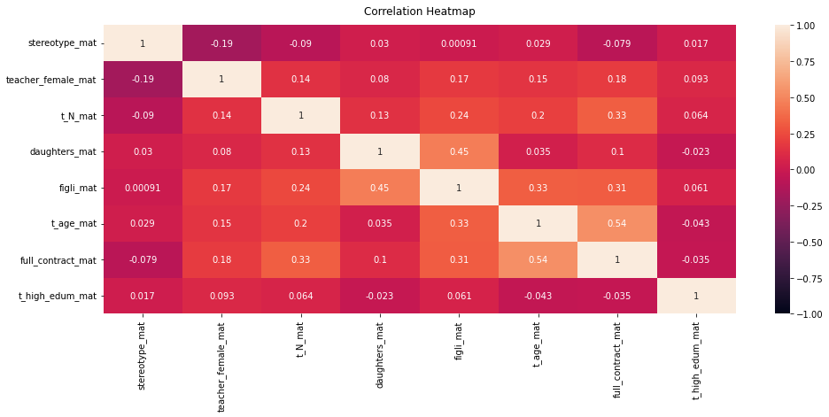

```python
### Visualizing correlation with heatmap
plt.figure(figsize=(16, 6))
heatmap = sns.heatmap(df_teacher.corr(), vmin=-1, vmax=1, annot=True)
heatmap.set_title('Correlation Heatmap', fontdict={'fontsize':12}, pad=12)
```

Next, I split the data into train and test sets, and use regresssion tree model to train the model. And eventually, we want to have a model such that we can predict a teachers' gender stereotypes with known teacher characteristics.

```python
X = teacher[['teacher_female_mat', 't_N_mat', 'daughters_mat', 'figli_mat', 't_age_mat', 'full_contract_mat', 't_high_edum_mat']]
y = teacher['stereotype_mat']
X_train, X_test, Y_train, Y_test = train_test_split(X, y, test_size = 0.3, random_state = 44)

model = DecisionTreeRegressor(random_state=44)
model.fit(X_train, Y_train)
predictions = model.predict(X_test)

rmse = mean_squared_error(Y_test, predictions, squared=False)
rmse
```

```
1.183121343615099
```

This model uses all teacher characteristics as dependent variables, and the root mean squared error is 1.18.

```python
### predictions 1
y_pred = model.predict([[1,1,2,3,30,0,1]])
y_pred
```

```
array([-0.17857344])
```

```python
### predictions 2
y_pred = model.predict([[0,0,0,3,40,1,0]])
y_pred
```

```
array([1.1098174])
```

From prediction 1 and 2, we know that a 30-year-old female math teacher borned in north Italy, who has 3 children and 2 of them are daughters, without full contract but with high education has much lower gender stereotype than a 40-year-old male math teacher not borned in north Italy, who has 3 sons, with full contract but without high education.

```python
X = teacher[['teacher_female_mat', 't_high_edum_mat']]
y = teacher['stereotype_mat']
X_train, X_test, Y_train, Y_test = train_test_split(X, y, test_size = 0.3, random_state = 44)

model = DecisionTreeRegressor(random_state=44)
model.fit(X_train, Y_train)
predictions = model.predict(X_test)

rmse = mean_squared_error(Y_test, predictions, squared=False)
rmse
```

```
0.9117866117392195
```

```python
### prediction 1
y_pred = model.predict([[1,1]])
y_pred
```

```
array([-0.46831336])
```

```python
### prediction 2
y_pred = model.predict([[0,0]])
y_pred
```

```
array([0.06863677])
```

For this new model, from prediction 1 and 2, we know that a female math teacher with high education has much lower gender stereotype than a male math teacher without high education.

And the root mean squared error is lower than the previous model.

```python
#### Classification by KMeans
from sklearn.cluster import KMeans
```

```python
### get the median of the stereotypes value
teacher['stereotype_mat'].quantile([.5])
```

```
0.5   -0.390028
Name: stereotype_mat, dtype: float64
```

```python
kmeans = KMeans(n_clusters=2)
kteacher = teacher[['teacher_female_mat', 't_N_mat', 'daughters_mat', 'figli_mat', 't_age_mat', 'full_contract_mat', 't_high_edum_mat']]
kmeans.fit(kteacher)
```

```
KMeans(n_clusters=2)
```

```python
kmeans.cluster_centers_
```

```
array([[ 0.86122449,  0.64897959,  0.09795918,  1.49387755, 56.04897959,
         0.92653061,  0.33061224],
       [ 0.75119617,  0.52631579,  0.12440191,  0.92344498, 36.81339713,
         0.55023923,  0.42105263]])
```

Create a new column for teacher dataframe called 'Cluster', which is a 1 for high stereotypes, and a 0 for low stereotypes.

```python
def converter(cluster):
    if cluster<= -0.390028:
        return 0
    else:
        return 1
```

```python
teacher['Cluster'] = teacher['stereotype_mat'].apply(converter)
teacher.head()
```

| INS_MAT8 | anno_scuola8 | female | stereotype_mat | stdinvalsi_mat8 | confidence_mat | high_edu_mother | teacher_female_mat | t_N_mat | mate_mate | figli_mat | daughters_mat | t_age_mat | full_contract_mat | t_high_edum_mat | gender | fem_stereotype_mat | fem_high_edu_mother | Cluster |
| --- | --- | --- | --- | --- | --- | --- | --- | --- | --- | --- | --- | --- | --- | --- | --- | --- | --- | --- |
| 10107.0 | 417 | 1 | -0.678292 | -0.218978 | NaN | 0 | 1 | 1 | 0 | 0 | 0 | 45 | 1 | 0 | Female | -0.678292 | 0 | 0 |
| 10108.0 | 417 | 1 | 0.457125 | -1.250173 | NaN | 0 | 0 | 0 | 0 | 0 | 0 | 50 | 1 | 1 | Female | 0.457125 | 0 | 1 |
| 10109.0 | 421 | 1 | -1.156041 | -1.326088 | NaN | 0 | 1 | 0 | 0 | 0 | 0 | 34 | 0 | 0 | Female | -1.156041 | 0 | 0 |
| 10209.0 | 423 | 1 | -1.626224 | -0.734575 | NaN | 0 | 1 | 0 | 0 | 2 | 1 | 59 | 1 | 0 | Female | -1.626224 | 0 | 0 |
| 10210.0 | 423 | 0 | -1.951072 | -0.476777 | NaN | 0 | 1 | 0 | 0 | 3 | 1 | 48 | 1 | 1 | Male | -0.000000 | 0 | 0 |

```python
from sklearn.metrics import confusion_matrix,classification_report
print(confusion_matrix(teacher['Cluster'],kmeans.labels_))
print(classification_report(teacher['Cluster'],kmeans.labels_))
```

```
[[126 101]
 [119 108]]
              precision    recall  f1-score   support

           0       0.51      0.56      0.53       227
           1       0.52      0.48      0.50       227

    accuracy                           0.52       454
   macro avg       0.52      0.52      0.51       454
weighted avg       0.52      0.52      0.51       454
```

## **Conclusion**

**In this project, the main question I investigate is whether math teachers' gender stereotypes have an impact on students' math performance. And I also conduct a robustness check for the exogeneity of the assignment of students to teachers with gender stereotypes. In summary, teachers' gender stereotypes have negative impacts on female students' math performace. And there is no supporting evidence that students assigned to teachers with different level of gender stereotypes are different, therefore validate the causal relationship between teachers' gender stereotypes and the worse math performance of female students.**